# Test a Perceptual Phenomenon

## Background Information

In a Stroop task, participants are presented with a list of words, with each word displayed in a color of ink. The participant’s task is to say out loud the color of the ink in which the word is printed. The task has two conditions: a congruent words condition, and an incongruent words condition. In the congruent words condition, the words being displayed are color words whose names match the colors in which they are printed: for example RED, BLUE. In the incongruent words condition, the words displayed are color words whose names do not match the colors in which they are printed: for example PURPLE, ORANGE. In each case, we measure the time it takes to name the ink colors in equally-sized lists. Each participant will go through and record a time from each condition.

## Questions For Investigation

As a general note, be sure to keep a record of any resources that you use or refer to in the creation of your project. You will need to report your sources as part of the project submission.

#### 1. What is our independent variable? What is our dependent variable?

Independent Variable: Word color congruency condition

Dependent Variable: Response time

#### 2. What is an appropriate set of hypotheses for this task? What kind of statistical test do you expect to perform? Justify your choices.

Now it’s your chance to try out the Stroop task for yourself. Go to this [link](https://www.google.com/url?q=https://faculty.washington.edu/chudler/java/ready.html&sa=D&ust=1499924829511000&usg=AFQjCNF_whwGBO8QBJuM73fnbRKk-Yct5Q), which has a Java-based applet for performing the Stroop task. Record the times that you received on the task (you do not need to submit your times to the site.) Now, download this [dataset](https://www.google.com/url?q=https://drive.google.com/file/d/0B9Yf01UaIbUgQXpYb2NhZ29yX1U/view?usp%3Dsharing&sa=D&ust=1499924829511000&usg=AFQjCNHdSvx40SSDWtldPsYlOKE6ctzubA) which contains results from a number of participants in the task. Each row of the dataset contains the performance for one participant, with the first number their results on the congruent task and the second number their performance on the incongruent task.

Hypotheses:

Let μC denoting the mean response time in congruent condition, μI denoting the mean response time in incongruent condition.

H0: Incongruent words condition does not impact response time (μC = μI)

H1: Incongruent words condition impact response time (μC ≠ μI)

Paired t-test is the suitable statistical test to perform on this dataset. This is because each participants have gone throught both conditions and the results could be paired up for comparison.

One point to note is that, if the participants in congruent and incongruent conditions are different, we will then need to perform 2 samples t-test instead. Paired t-test is only applicable for same participants group and in the case that we are able to pair up their results in both conditions.

#### 3. Report some descriptive statistics regarding this dataset. Include at least one measure of central tendency and at least one measure of variability.

Firstly we will load the dataset and take a glimpse of the data.

```python
# import all necessary packages and functions.
import csv
import numpy as np
import pandas as pd
from IPython.display import display
%matplotlib inline
import matplotlib.pyplot as plt
from collections import Counter

# read in the data by pandas
stroopdata = pd.read_csv('stroopdata.csv')
display(stroopdata.head())
```

|  | Congruent | Incongruent |
| --- | --- | --- |
| 0 | 12.079 | 19.278 |
| 1 | 16.791 | 18.741 |
| 2 | 9.564 | 21.214 |
| 3 | 8.630 | 15.687 |
| 4 | 14.669 | 22.803 |

Then we will take a look on some descriptive statistics of the dataset.

```python
print 'Mean:'
display(stroopdata.mean())
print 'Median:'
display(stroopdata.median())

print 'Sample Standard Deviation:'
display(stroopdata.std())
```

```
Mean:
```

```
Congruent      14.051125
Incongruent    22.015917
dtype: float64
```

```
Median:
```

```
Congruent      14.3565
Incongruent    21.0175
dtype: float64
```

```
Sample Standard Deviation:
```

```
Congruent      3.559358
Incongruent    4.797057
dtype: float64
```

#### 4. Provide one or two visualizations that show the distribution of the sample data. Write one or two sentences noting what you observe about the plot or plots.

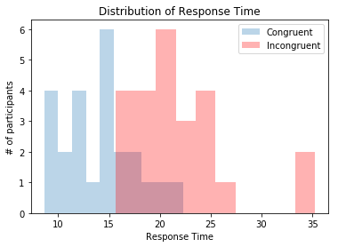

```python
plt.figure(1)
plt.hist(stroopdata.Congruent, alpha=0.3, label='Congruent')
plt.hist(stroopdata.Incongruent, color='r', alpha=0.3, label='Incongruent')

#add label
plt.xlabel('Response Time')
plt.ylabel('# of participants')
plt.title('Distribution of Response Time')
plt.legend()
```

From the plot, it is quite obvious that the incongruent condition is having a right shift to the congruent condition, indicating that response time in incongruent conditions is slower in general.

#### 5. Now, perform the statistical test and report your results. What is your confidence level and your critical statistic value? Do you reject the null hypothesis or fail to reject it? Come to a conclusion in terms of the experiment task. Did the results match up with your expectations?

We will make use of the `SciPy` library to perform the paired t-test.

```python
from scipy import stats

display(stats.ttest_rel(stroopdata.Congruent, stroopdata.Incongruent))
```

```
Ttest_relResult(statistic=-8.020706944109957, pvalue=4.1030005857111781e-08)
```

I will pick a 0.01 confidence level for this experiment, as this is a well-known pyschology phenomenon. For confidence level of 0.01, I can reject the H0(null hypothesis) with a p-value of 4.1030005857111781e-08.

To conclude, incongruent words condition impact response time. This match up with my expectations as I experienced the same when I tried out the experiement.

#### 6. Optional: What do you think is responsible for the effects observed? Can you think of an alternative or similar task that would result in a similar effect? Some research about the problem will be helpful for thinking about these two questions!

In fact, I am currently a psychology student so I did some research on stroop effect. One popular explanation is that reading from text is an (almost) automatic process that doesn't require much of central processing or attention. Hoever, in the incongruent condition, the task is no longer a automatic reading task but requirment mental resources to process what is the correct answer and thus a slower response time is observed.

There are also some other relevant phenomenon like naming a shape (square/triangle/reactangle) while the it is marked with wrong shape label. Basically this would happen in the cases that you are asked to read out something not trivial in the text or contradicting the text.

## References

1. [Stroop effect - Wikipedia](https://en.wikipedia.org/wiki/Stroop_effect)
2. [scipy.stats.ttest_rel - SciPy.org](https://docs.scipy.org/doc/scipy-0.19.0/reference/generated/scipy.stats.ttest_rel.html)